# Regresión lineal 1

Introducción a R. Ciencias Políticas

Javier Kniffki

javierkniffki@gmail.com

2021-12-13

# Lectura de los datos

En esta ocasión vamos a leer los datos depositados en el repositorio de github para agilizar el proceso. Pero muchas veces trabajaremos con datos a nivel local para leer estos conviene recordar unas cuantas funciones y algunas nociones para trabjar con archivos en R

## Repaso gestión de archivos en R

Para verificar el entorno de trabajo es decir la carpeta donde R esta ahora mismo empleamos `getwd()` para cambiar dicho entorno podemos emplear la función `setwd()`.

```r
# Cambiando el directorio de trabajo a Rproject la carpeta de data
setwd("C:/Users/UserName/Documents/Rproject/data")
```

Recuerda que en R **“\”** es un scape character que sirve para identificar otras cadenas de texto asi que es necesario poner **“\\”** en la especificación de la dirección o emplear directamente **“/”**.

Correcto:  
“C:/Users/UserName/Documents/Rproject/data”  
“C:\\Users\\UserName\\Documents\\Rproject\\data”

Incorrecto:  
“C:\Users\UserName\Documents\Rproject\data”

Para listar los archivos de una carpeta empleamos la función `ls("directorio/donde/listar/archivos")` el resultado lo podemos guardad en un vector y acceder a el de la forma habitual. Otra función interesante es `file.choose()` la cual abrira un navegador de archivos y nos permitira seleccionar un archivo o carpeta concreta de forma manual imprimiendo su path en la consola. Recuerda que tambien podemos guardar este valor en un objeto `archivo <- file.choose()`

Si estamos trabajando en un proyecto el working directory sera el del proyecto.

## Lectura

A continuación pasamos a leer los datos. En este caso se trata de un `.csv` **Comma separeted values**

```r
# para leer en local
file.exists("./datos/CD_hdi_corr_sc.csv")
```

```
## [1] TRUE
```

```r
# función de R base
datos <- read.csv("./datos/CD_hdi_corr_sc.csv")
```

# Exploración inical

Exploramos de forma habitual

```r
str(datos)
```

```
## 'data.frame':    7488 obs. of  8 variables:
##  $ Entity                     : chr  "Afghanistan" "Afghanistan" "Afghanistan" "Afghanistan" ...
##  $ Code                       : chr  "AFG" "AFG" "AFG" "AFG" ...
##  $ Continent                  : chr  "Asia" "Asia" "Asia" "Asia" ...
##  $ Year                       : int  1990 1991 1992 1993 1994 1995 1996 1997 1998 1999 ...
##  $ avg_years_school           : num  1.49 1.6 1.6 1.7 1.8 1.9 1.9 2 2 2.1 ...
##  $ Corruption_perception_index: int  NA NA NA NA NA NA NA NA NA NA ...
##  $ PopEstimate                : int  12412311 13299016 14485543 15816601 17075728 18110662 18853444 19357126 19737770 20170847 ...
##  $ Human_Dev_index            : num  NA NA NA NA NA NA NA NA NA NA ...
```

```r
summary(datos)
```

```
##     Entity              Code            Continent              Year
##  Length:7488        Length:7488        Length:7488        Min.   :1990
##  Class :character   Class :character   Class :character   1st Qu.:1998
##  Mode  :character   Mode  :character   Mode  :character   Median :2006
##                                                           Mean   :2006
##                                                           3rd Qu.:2013
##                                                           Max.   :2021
##
##  avg_years_school Corruption_perception_index  PopEstimate
##  Min.   : 0.290   Min.   : 8.00               Min.   :7.620e+02
##  1st Qu.: 4.800   1st Qu.:28.25               1st Qu.:3.635e+05
##  Median : 7.800   Median :38.00               Median :4.557e+06
##  Mean   : 7.429   Mean   :42.99               Mean   :2.819e+07
##  3rd Qu.:10.100   3rd Qu.:56.00               3rd Qu.:1.692e+07
##  Max.   :14.100   Max.   :92.00               Max.   :1.444e+09
##  NA's   :2669     NA's   :6266
##  Human_Dev_index
##  Min.   :0.1990
##  1st Qu.:0.5290
##  Median :0.6800
##  Mean   :0.6551
##  3rd Qu.:0.7830
##  Max.   :0.9530
##  NA's   :2731
```

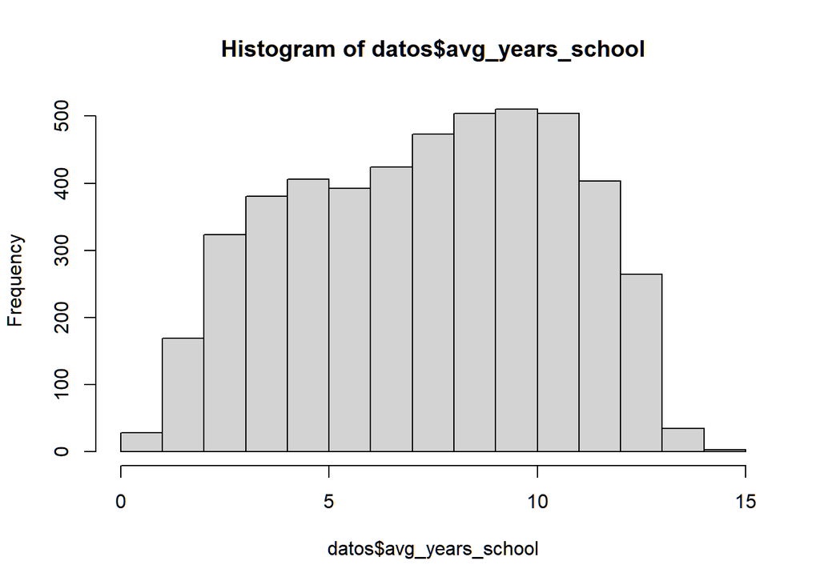

```r
hist(datos$avg_years_school)
```

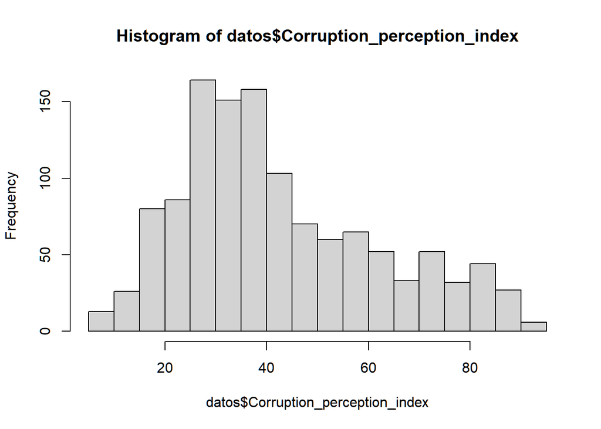

```r
hist(datos$Corruption_perception_index)
```

```r
mean(datos$Corruption_perception_index)
```

```
## [1] NA
```

```r
mean(datos$Corruption_perception_index, na.rm = T)
```

```
## [1] 42.98936
```

# Transformaciones

Normalmente aprobecaharíamos los datos de panel para el ajuste de modelos más fidedignos aqui vamos a sacar una media del rango temporal disponible y revertir el índice de corrupción para hacerlo más sencillo a la hora de interpretar.

```r
library(dplyr)

# función propia que no tiene en cuenta los NA
mimedia <- function(x) { mean(x, na.rm = T)}

# Seleción de variables, agrupación y calculo
 datos_mod <- datos |> select(Entity,avg_years_school,Corruption_perception_index,PopEstimate) |> group_by(Entity) |> summarise_all(mimedia)

# quitamos casos que no esten completos
datos_mod <- datos_mod[complete.cases(datos_mod),]


 # recuperamos los continentes
 datos_mod2 <- datos_mod |> left_join(unique(datos[,c("Entity","Continent")]))


 # cambiar la variable corruption index
 datos_mod2 <- datos_mod2 |> mutate(Corruption_perception_index = 100 - Corruption_perception_index)


 head(datos_mod2)
```

```
## # A tibble: 6 x 5
##   Entity      avg_years_school Corruption_perception_index PopEstimate Continent
##   <chr>                  <dbl>                       <dbl>       <dbl> <chr>
## 1 Afghanistan             2.57                        87.9   26068568. Asia
## 2 Albania                 8.88                        64.9    3038523. Europe
## 3 Algeria                 6.21                        65.1   34264125. Africa
## 4 Angola                  4.65                        80.7   20994920. Africa
## 5 Argentina               9.04                        64.3   39124059. South Am~
## 6 Armenia                10.9                         65      3055799. Asia
```

# Modelos

El modelo lineal básico ..

$$Y_{i}=\beta _{0}+\beta _{1}X_{i1}+\beta _{2}X_{i2}+\ldots +\beta _{p}X_{ip}+\epsilon_{i}$$

```r
mod1 <- lm(formula = Corruption_perception_index ~ avg_years_school ,data = datos_mod2)

summary(mod1)
```

```
##
## Call:
## lm(formula = Corruption_perception_index ~ avg_years_school,
##     data = datos_mod2)
##
## Residuals:
##     Min      1Q  Median      3Q     Max
## -40.673  -9.717   1.710  10.041  36.533
##
## Coefficients:
##                  Estimate Std. Error t value Pr(>|t|)
## (Intercept)       86.0829     2.8433   30.28   <2e-16 ***
## avg_years_school  -4.0586     0.3627  -11.19   <2e-16 ***
## ---
## Signif. codes:  0 '***' 0.001 '**' 0.01 '*' 0.05 '.' 0.1 ' ' 1
##
## Residual standard error: 14.8 on 176 degrees of freedom
## Multiple R-squared:  0.4157, Adjusted R-squared:  0.4123
## F-statistic: 125.2 on 1 and 176 DF,  p-value: < 2.2e-16
```

```r
confint(mod1)
```

```
##                     2.5 %    97.5 %
## (Intercept)      80.47163 91.694189
## avg_years_school -4.77452 -3.342769
```

Nuestro modelo entonces sería:

$$Corruption\_perception \ =\ 86.0829 + -4.0586*avg\_years\_shcool+\epsilon$$

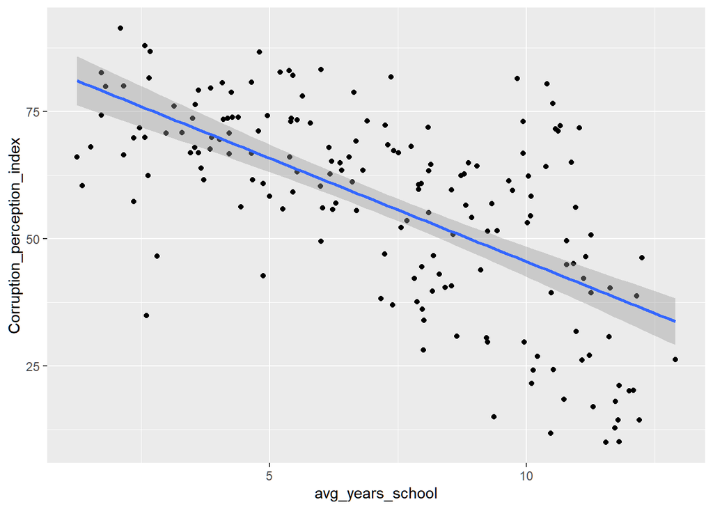

```r
library(ggplot2)

ggplot(data = datos_mod2,aes(x = avg_years_school, y = Corruption_perception_index)) +
  geom_point() +
  geom_smooth(method = "lm")
```

```r
mod2 <- lm(formula = Corruption_perception_index ~ poly(avg_years_school,2) ,data = datos_mod2)

summary(mod2)
```

```
##
## Call:
## lm(formula = Corruption_perception_index ~ poly(avg_years_school,
##     2), data = datos_mod2)
##
## Residuals:
##     Min      1Q  Median      3Q     Max
## -36.467  -9.603   1.062   9.017  37.326
##
## Coefficients:
##                            Estimate Std. Error t value Pr(>|t|)
## (Intercept)                   56.79       1.08  52.600  < 2e-16 ***
## poly(avg_years_school, 2)1  -165.65      14.40 -11.499  < 2e-16 ***
## poly(avg_years_school, 2)2   -47.57      14.40  -3.302  0.00116 **
## ---
## Signif. codes:  0 '***' 0.001 '**' 0.01 '*' 0.05 '.' 0.1 ' ' 1
##
## Residual standard error: 14.4 on 175 degrees of freedom
## Multiple R-squared:  0.4499, Adjusted R-squared:  0.4436
## F-statistic: 71.57 on 2 and 175 DF,  p-value: < 2.2e-16
```

```r
confint(mod2)
```

```
##                                 2.5 %     97.5 %
## (Intercept)                  54.66181   58.92363
## poly(avg_years_school, 2)1 -194.07878 -137.21904
## poly(avg_years_school, 2)2  -75.99581  -19.13607
```

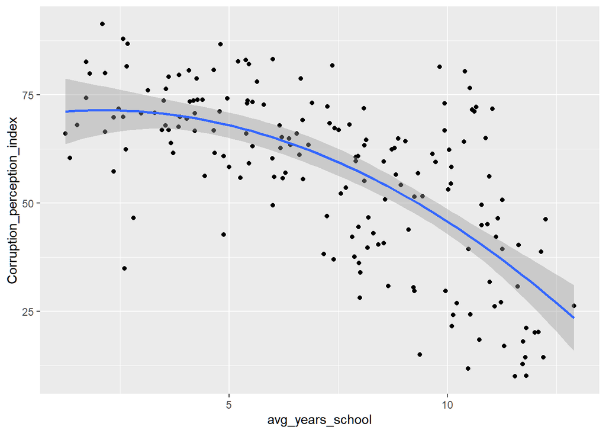

```r
ggplot(data = datos_mod2,aes(x = avg_years_school, y = Corruption_perception_index)) +
  geom_point() +
  geom_smooth(method = "lm",formula = y ~ poly(x,2))
```

El segundo modelo quedaría asi:

# Diagnóstico

Para evaluar un modelo lineal es importantante tener en cuenta estas 4 condiciones:

- Linealidad
- Homocedasticidad ( $Var(e_i) = \sigma^2$ con $\sigma^2$ constante )
- Normalidad: ( $\epsilon_i \sim N(0,\sigma^2)$ )
- Independencia de los errores

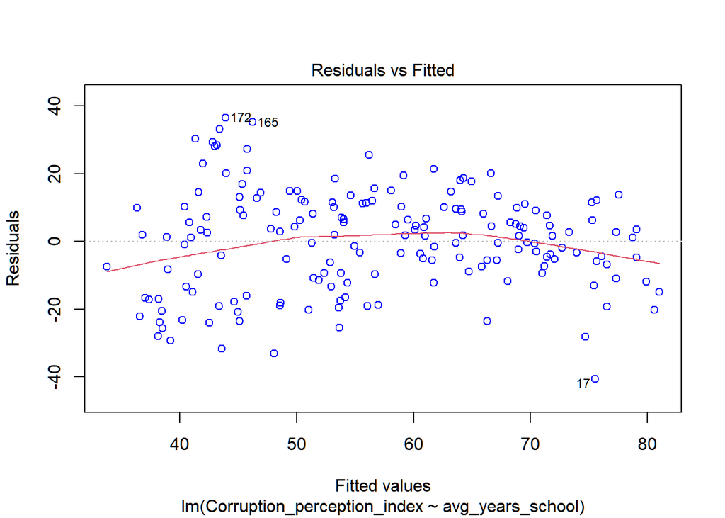

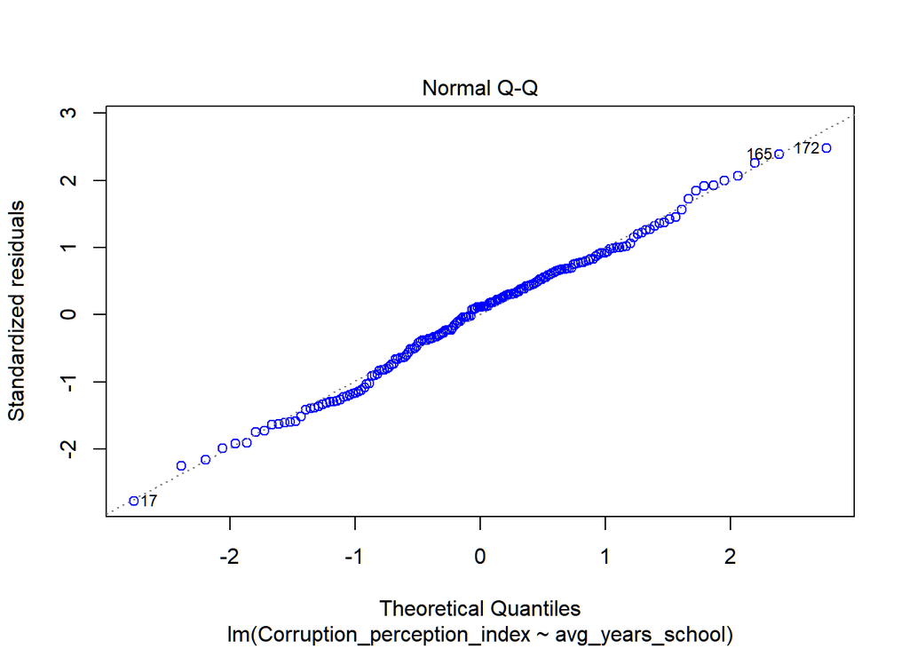

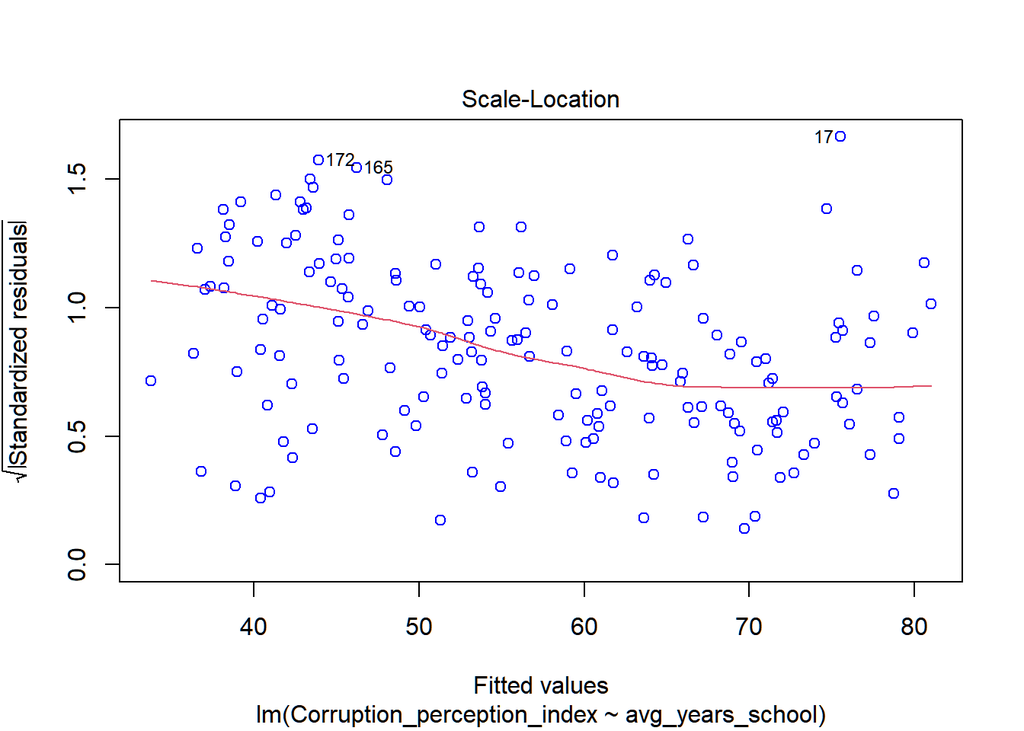

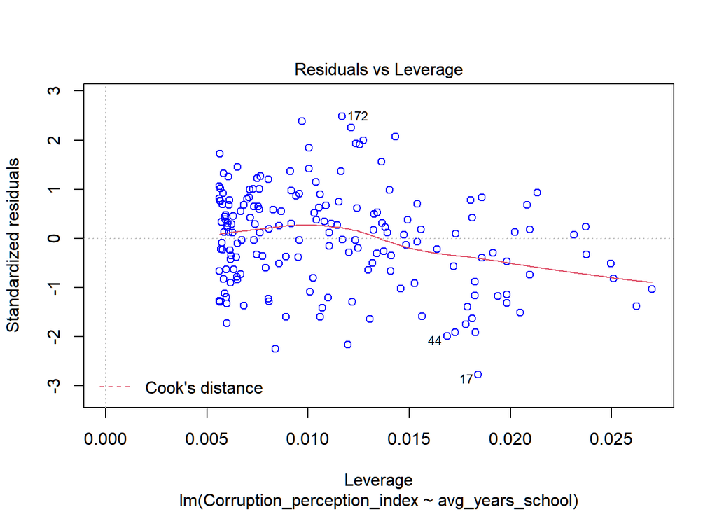

```r
plot(mod1, col = "blue")
```

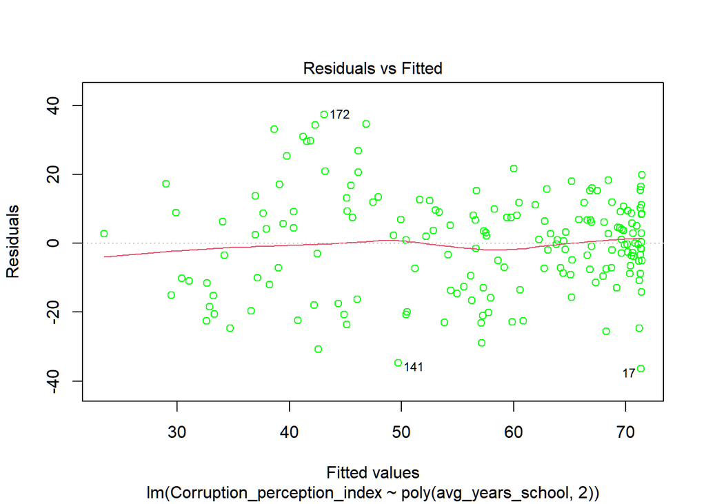

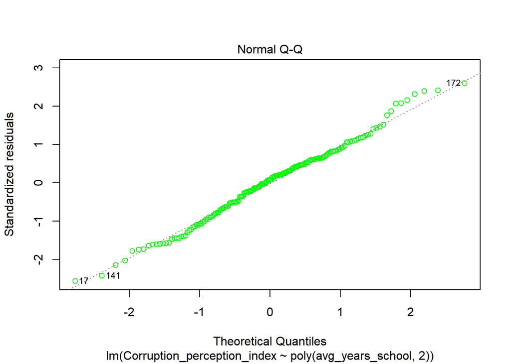

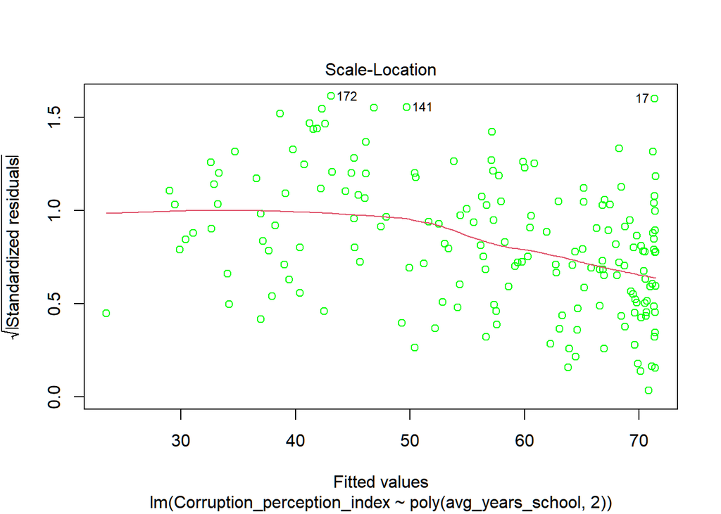

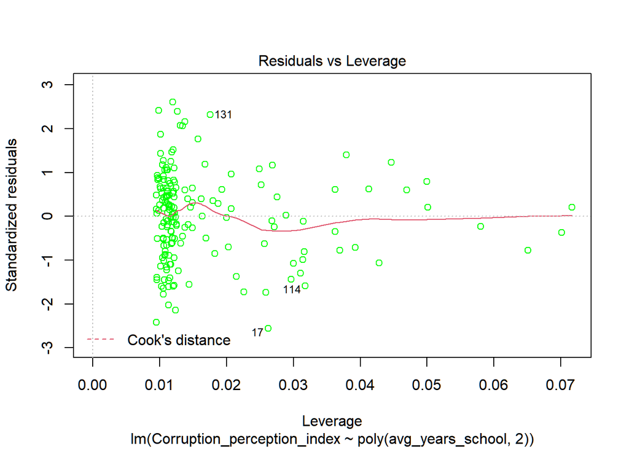

```r
plot(mod2, col = "green")
```

# Comunicando Resultados

## Tablas comparativas

```r
library(report)
library(stargazer)

# hacemos otro modelo para incluirlo en la tabla

mod3 <- lm(formula = Corruption_perception_index ~ avg_years_school + log(PopEstimate) ,data = datos_mod2)

stargazer(mod1,mod2,mod3,type = "text")
```

[output not shown]

## Texto

```r
library(report)
report(mod2)
```

[output not shown]

## Gráfico

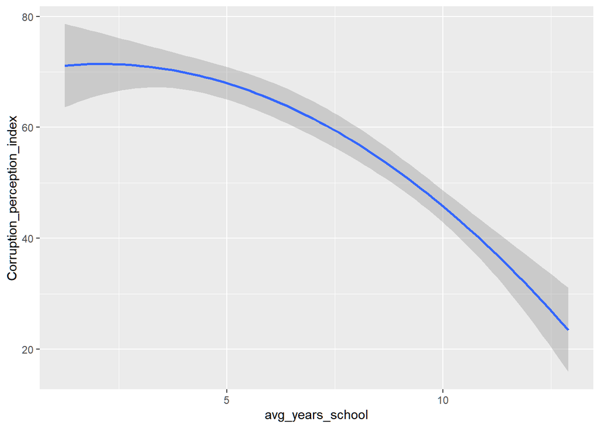

```r
p1 <- ggplot(data = datos_mod2,aes(x = avg_years_school, y = Corruption_perception_index)) +
  geom_smooth(method = "lm",formula = y ~ poly(x,2))

p1
```

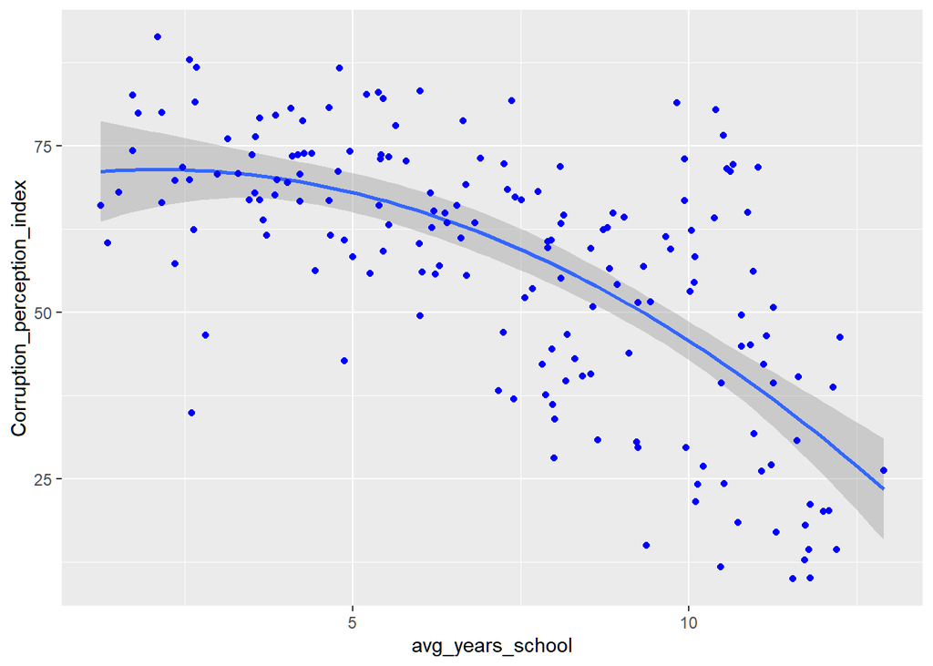

```r
p1 + geom_point(color = "blue")
```

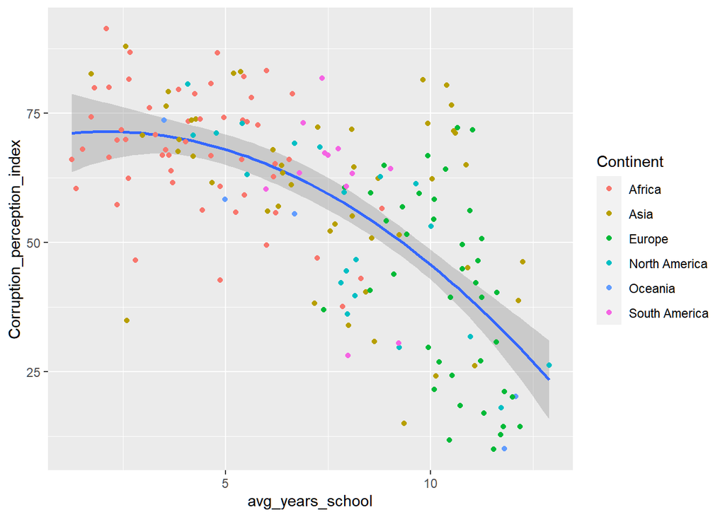

```r
p1 + geom_point(aes(color = Continent))
```

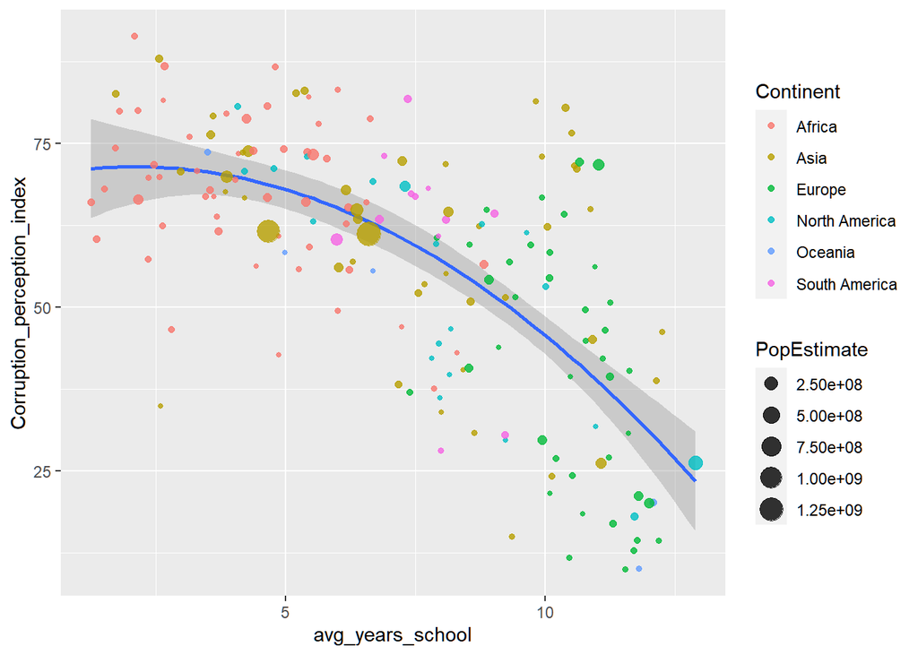

```r
p1 + geom_point(aes(color = Continent,size = PopEstimate),alpha = 0.8)
```

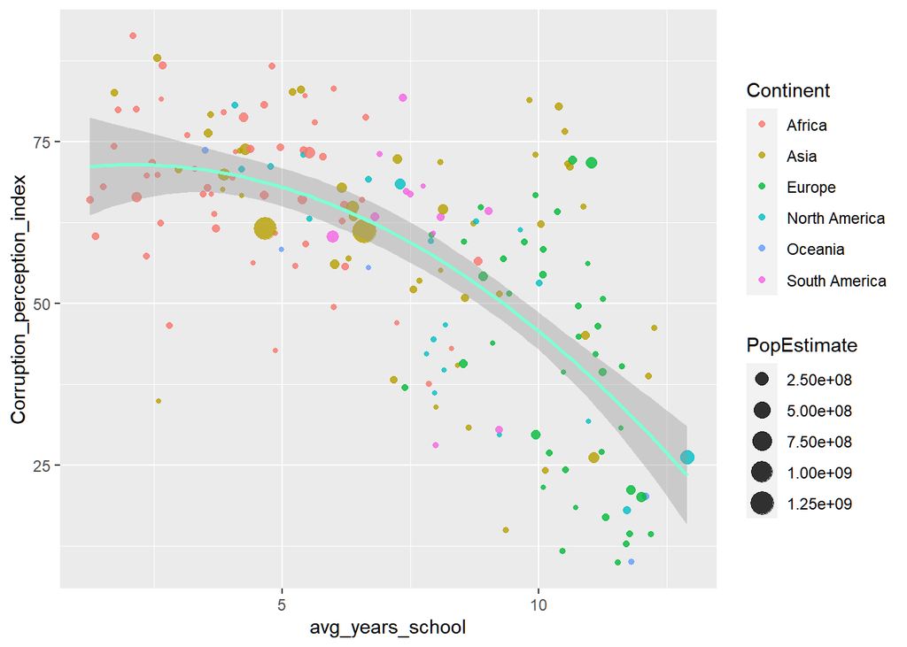

```r
p2 <- ggplot(data = datos_mod2,aes(x = avg_years_school, y = Corruption_perception_index)) +
  geom_point(aes(color = Continent,size = PopEstimate),alpha = 0.8) +
  geom_smooth(method = "lm",formula = y ~ poly(x,2),color = "#7FFFD4")

p2
```

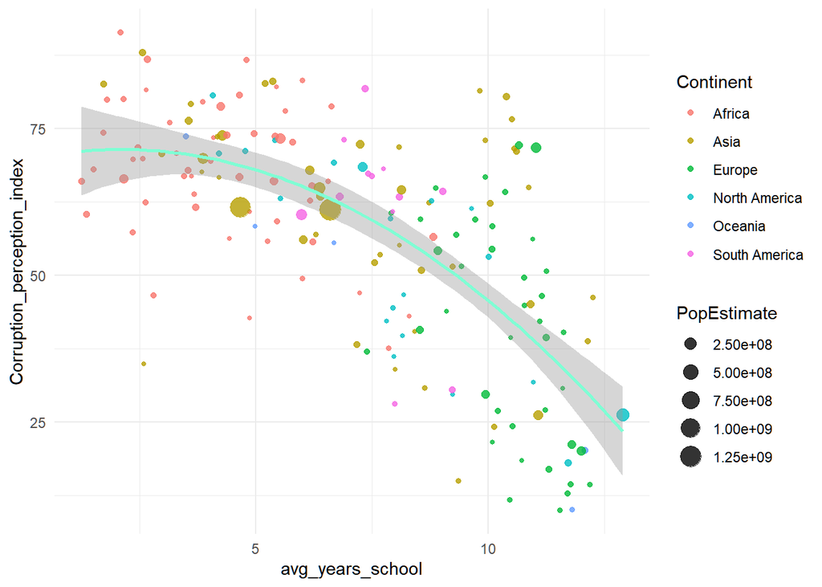

```r
p2 <- p2 + theme_minimal()
p2
```

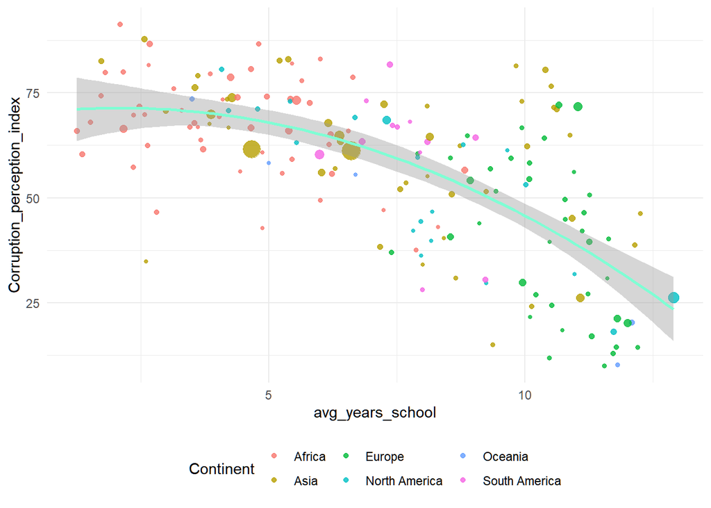

```r
p2 <- p2 + guides(size = "none") + theme(legend.position = "bottom")
p2
```

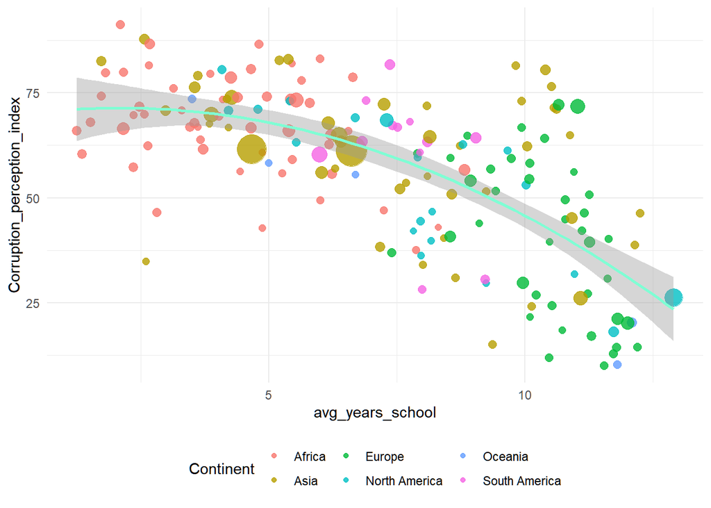

```r
p2 <- p2 + scale_size(range = c(2,10))
p2
```

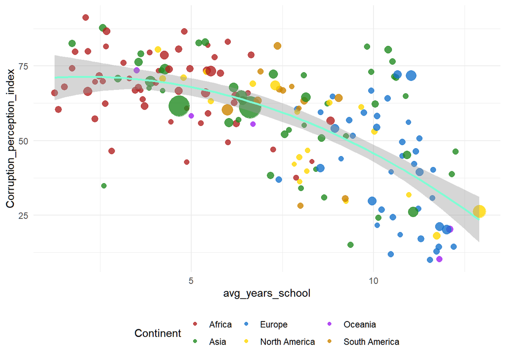

```r
p2 <- p2 + scale_color_manual(values = c("#b22222","forestgreen","dodgerblue3","gold","purple","orange3"))
p2
```

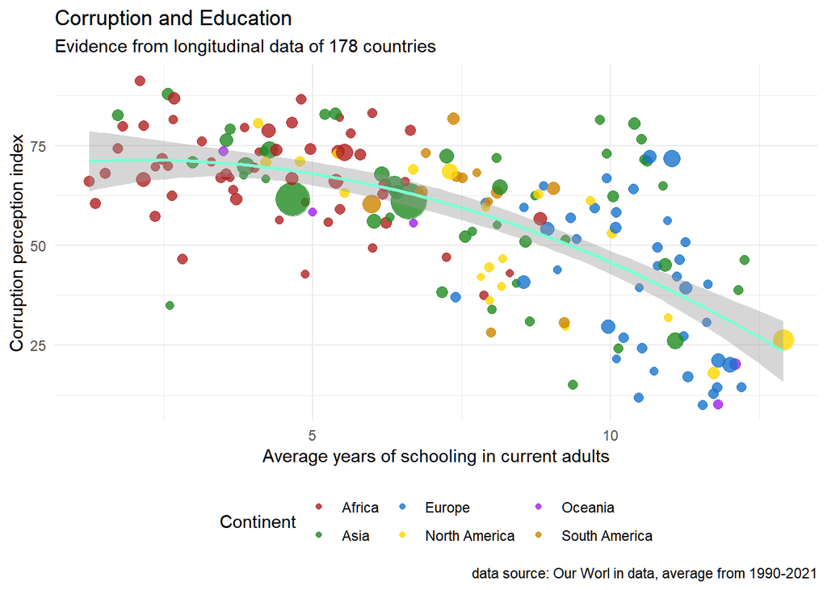

```r
p2 <- p2 + labs(title = "Corruption and Education",
           subtitle = "Evidence from longitudinal data of 178 countries",
           caption = "data source: Our Worl in data, average from 1990-2021",
           x = "Average years of schooling in current adults",y = "Corruption perception index")
p2
```

# Ejercicios

1. Empleando el objeto **datos** extrae los valores de Francia ¿cuantos valores perdidos hay en la variable referida a la percepción de la corrupción?

**Ver la respuesta**

```r
fr <- datos[datos$Code == "FRA",]
head(fr)
```

```
##      Entity Code Continent Year avg_years_school Corruption_perception_index
## 2305 France  FRA    Europe 1990             7.33                          NA
## 2306 France  FRA    Europe 1991             7.50                          NA
## 2307 France  FRA    Europe 1992             7.80                          NA
## 2308 France  FRA    Europe 1993             8.10                          NA
## 2309 France  FRA    Europe 1994             8.40                          NA
## 2310 France  FRA    Europe 1995             8.80                          NA
##      PopEstimate Human_Dev_index
## 2305    56666861           0.779
## 2306    56913580           0.788
## 2307    57147213           0.798
## 2308    57370375           0.804
## 2309    57587122           0.818
## 2310    57801887           0.825
```

```r
sum(is.na(fr$Corruption_perception_index))
```

```
## [1] 25
```

2. Construye un modelo con la variable **Human_Dev_index** como variable independiente y **Corruption_perception_index** como dependiente. Emplea la media para cada pais en el rango de años de los datos iniciales ¿Su ajuste ($R^2$) es mejor que el del objeto mod1 ?

**Ver la respuesta**

```r
# función propia que no tiene en cuenta los NA
mimedia <- function(x) { mean(x, na.rm = T)}

# Seleción de variables, agrupación y calculo
 datos_ej2 <- datos |> select(Entity,Human_Dev_index,Corruption_perception_index) |> group_by(Entity) |> summarise_all(mimedia)

# quitamos casos que no esten completos
datos_ej2 <- datos_ej2[complete.cases(datos_ej2),]

# cambiar la variable corruption index
datos_ej2 <- datos_ej2 |> mutate(Corruption_perception_index = 100 - Corruption_perception_index)

# ajustamos el modelo
mod_ej2 <- lm(data = datos_ej2,Corruption_perception_index~Human_Dev_index)


# R cuadrado
summary(mod_ej2)$r.squared
```

```
## [1] 0.5350781
```

```r
summary(mod_ej2)$r.squared > summary(mod1)$r.squared
```

```
## [1] TRUE
```

3. Obten el gráfico de dispersión con la recta de la regresión para el modelo del ejercicio 2

**Ver la respuesta**

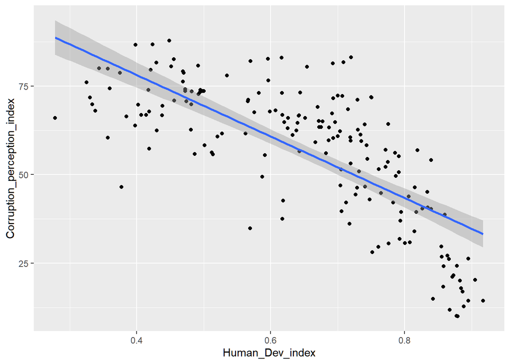

```r
ggplot(data = datos_ej2,aes(x = Human_Dev_index, y = Corruption_perception_index)) +
  geom_point() +
  geom_smooth(method = "lm")
```